# Mental Health, Workplace Wellbeing and Access to Support

## Business Context:

Organisations need to understand factors associated with mental-health wellbeing and treatment engagement because mental-health issues can affect employees' wellbeing, workplace experience and ability to engage with work. The purpose of this project is to explore patterns between demographic, workplace, lifestyle and mental-health-related variables and identify relationships that may be useful for organisational decision-making.

### Dataset:

The dataset(Alam Shihab, 2025) contains information including Gender, Country, Occupation, SelfEmployed, FamilyHistory, DaysIndoors, Treatment, HabitsChange, MentalHealthHistory, Increasing Stress, MoodSwings, SocialWeakness, CopingStruggles, WorkInterest, SocialWeakness, MentalHealthInterview, CareOptions. This data will help us in finding patterns and possible solutions.

### Potential Decisions:

As our audience is organisations so we can let them know after analysis:

Where wellbeing support may need more attention

Whether different groups show different patters

Whether workplace or lifestyle affects mental health

## Data Exploration:

We will load the given dataset and explore tha columns and rows.

```python
import pandas as pd

healthcare = pd.read_csv("D:\Docs\MSc Data Science, AI and Digital Business\M512 - Data Visualization and Communication\Mental Health dataset1.csv")
```

pandas(The pandas development team (2026)) is a python package that we will use to for dataset exploration and pre-processing or cleaning. In pandas .read_csv() is a function that that takes the path of the file saved locally in the computer and load that csv file.

```python
healthcare.shape
```

```
(261328, 17)
```

```python
healthcare.head()
```

|  | Gender | Country | Occupation | SelfEmployed | FamilyHistory | Treatment | DaysIndoors | HabitsChange | MentalHealthHistory | IncreasingStress | MoodSwings | SocialWeakness | CopingStruggles | WorkInterest | SocialWeakness.1 | MentalHealthInterview | CareOptions |
| --- | --- | --- | --- | --- | --- | --- | --- | --- | --- | --- | --- | --- | --- | --- | --- | --- | --- |
| 0 | Female | UK | Others | No | Yes | No | 15-30 days | No | Yes | Yes | High | No | Yes | Maybe | No | No | No |
| 1 | Female | USA | Housewife | No | Yes | No | 15-30 days | Maybe | Maybe | Yes | High | Maybe | Yes | Maybe | Maybe | No | Not sure |
| 2 | Female | Canada | Others | No | No | Yes | More than 2 months | Maybe | No | No | Medium | No | No | No | No | No | Not sure |
| 3 | Female | Canada | Corporate | No | Yes | Yes | Go out Every day | No | Maybe | No | Medium | No | No | Maybe | No | No | Not sure |
| 4 | Female | UK | Corporate | No | No | Yes | More than 2 months | Yes | No | Maybe | Medium | Maybe | No | Maybe | Maybe | No | Not sure |

```python
healthcare.tail()
```

|  | Gender | Country | Occupation | SelfEmployed | FamilyHistory | Treatment | DaysIndoors | HabitsChange | MentalHealthHistory | IncreasingStress | MoodSwings | SocialWeakness | CopingStruggles | WorkInterest | SocialWeakness.1 | MentalHealthInterview | CareOptions |
| --- | --- | --- | --- | --- | --- | --- | --- | --- | --- | --- | --- | --- | --- | --- | --- | --- | --- |
| 261323 | Male | USA | Business | No | No | No | 15-30 days | Maybe | No | No | Low | Maybe | Yes | No | Maybe | Maybe | Not sure |
| 261324 | Male | USA | Business | Yes | Yes | Yes | 15-30 days | Maybe | No | No | Low | Maybe | Yes | No | Maybe | Maybe | Not sure |
| 261325 | Male | USA | Business | No | Yes | No | 15-30 days | Maybe | No | No | Low | Maybe | Yes | No | Maybe | No | No |
| 261326 | Male | USA | Business | No | Yes | Yes | 15-30 days | Maybe | No | No | Low | Maybe | Yes | No | Maybe | No | Yes |
| 261327 | Male | USA | Business | No | Yes | Yes | 15-30 days | Maybe | No | No | Low | Maybe | Yes | No | Maybe | No | Yes |

In pandas .shape give us tha toal number of rows and columns in loaded csv file. In our case we have 261328 rows and 17 columns. The .head() and .tail() functions give us tha first and last 5 entries of the dataset respectively to see if the dataset has loaded properly.

```python
healthcare.info()
```

```
<class 'pandas.core.frame.DataFrame'>
RangeIndex: 261328 entries, 0 to 261327
Data columns (total 17 columns):
 #   Column                 Non-Null Count   Dtype
---  ------                 --------------   -----
 0   Gender                 261328 non-null  object
 1   Country                261328 non-null  object
 2   Occupation             261328 non-null  object
 3   SelfEmployed           256972 non-null  object
 4   FamilyHistory          261328 non-null  object
 5   Treatment              261328 non-null  object
 6   DaysIndoors            261328 non-null  object
 7   HabitsChange           261328 non-null  object
 8   MentalHealthHistory    261328 non-null  object
 9   IncreasingStress       261328 non-null  object
 10  MoodSwings             261328 non-null  object
 11  SocialWeakness         261328 non-null  object
 12  CopingStruggles        261328 non-null  object
 13  WorkInterest           261328 non-null  object
 14  SocialWeakness.1       261328 non-null  object
 15  MentalHealthInterview  261328 non-null  object
 16  CareOptions            261328 non-null  object
dtypes: object(17)
memory usage: 33.9+ MB
```

The .info() function returns the datatypes, number of records, column names. This is useful to decide whether the datatype are correct for next steps or do we need to change datatypes. As of this finding, all of the datatypes are good.

## Data Pre-processing:

Data pre-processing is the most important step because if we do not clean and structured data, we cannot get actual results. We will find empty values, invalid entries etc. in this step.

```python
healthcare.isnull().sum()
```

```
Gender                      0
Country                     0
Occupation                  0
SelfEmployed             4356
FamilyHistory               0
Treatment                   0
DaysIndoors                 0
HabitsChange                0
MentalHealthHistory         0
IncreasingStress            0
MoodSwings                  0
SocialWeakness              0
CopingStruggles             0
WorkInterest                0
SocialWeakness.1            0
MentalHealthInterview       0
CareOptions                 0
dtype: int64
```

The isnull() is used to check the missing values. In out dataset column SelfEmployed has 4356 null entries and we cannot assume these entries and take an average so will remove these entries. Our dataset is quite big so it will hurt the final analysis.

```python
healthcare = healthcare.dropna(subset=['SelfEmployed'])
```

```python
healthcare.isnull().sum()
```

```
Gender                   0
Country                  0
Occupation               0
SelfEmployed             0
FamilyHistory            0
Treatment                0
DaysIndoors              0
HabitsChange             0
MentalHealthHistory      0
IncreasingStress         0
MoodSwings               0
SocialWeakness           0
CopingStruggles          0
WorkInterest             0
SocialWeakness.1         0
MentalHealthInterview    0
CareOptions              0
dtype: int64
```

No more missing entries. The .dropna() function check the given column entries if the value is missing it drops that entire row.

```python
healthcare.duplicated().sum()
```

```
174897
```

In python pandas .duplicated() function returns the values that are exactly duplicated with other values. In our dataset we 174897 duplicated entries so we will remove these values to get the accurate results. This removal will leave us with substantial clean dataset.

```python
healthcare = healthcare.drop_duplicates()
```

```python
healthcare.shape
```

```
(82075, 17)
```

```python
print(
    (healthcare['SocialWeakness'] == healthcare['SocialWeakness.1']).all()
)
```

```
True
```

SocialWeakness and SocialWeakness.1 have the same entries so we can delete SocialWeakness.1 column as it does not serve any purpose.

```python
healthcare = healthcare.drop(columns=['SocialWeakness.1'])
healthcare.head()
```

|  | Gender | Country | Occupation | SelfEmployed | FamilyHistory | Treatment | DaysIndoors | HabitsChange | MentalHealthHistory | IncreasingStress | MoodSwings | SocialWeakness | CopingStruggles | WorkInterest | MentalHealthInterview | CareOptions |
| --- | --- | --- | --- | --- | --- | --- | --- | --- | --- | --- | --- | --- | --- | --- | --- | --- |
| 0 | Female | UK | Others | No | Yes | No | 15-30 days | No | Yes | Yes | High | No | Yes | Maybe | No | No |
| 1 | Female | USA | Housewife | No | Yes | No | 15-30 days | Maybe | Maybe | Yes | High | Maybe | Yes | Maybe | No | Not sure |
| 2 | Female | Canada | Others | No | No | Yes | More than 2 months | Maybe | No | No | Medium | No | No | No | No | Not sure |
| 3 | Female | Canada | Corporate | No | Yes | Yes | Go out Every day | No | Maybe | No | Medium | No | No | Maybe | No | Not sure |
| 4 | Female | UK | Corporate | No | No | Yes | More than 2 months | Yes | No | Maybe | Medium | Maybe | No | Maybe | No | Not sure |

The output shows that SocialWeakness.1 column has been removed successfully.

```python
print(healthcare.dtypes)
```

```
Gender                   object
Country                  object
Occupation               object
SelfEmployed             object
FamilyHistory            object
Treatment                object
DaysIndoors              object
HabitsChange             object
MentalHealthHistory      object
IncreasingStress         object
MoodSwings               object
SocialWeakness           object
CopingStruggles          object
WorkInterest             object
MentalHealthInterview    object
CareOptions              object
dtype: object
```

```python
print(healthcare.nunique().sort_values())
```

```
Gender                    2
SelfEmployed              2
FamilyHistory             2
Treatment                 2
CopingStruggles           2
HabitsChange              3
MentalHealthHistory       3
IncreasingStress          3
MoodSwings                3
SocialWeakness            3
WorkInterest              3
MentalHealthInterview     3
CareOptions               3
Occupation                5
DaysIndoors               5
Country                  35
dtype: int64
```

All of the columns have object datatype and mostly columns have 2 or 3 uniques values as we can se Yes or No so it is necessary to check whether there any case-sensitive values or spelling inconsistensies.

```python
categorical_columns = healthcare.select_dtypes(include='object').columns

for column in categorical_columns:
    print(f"\n{column}:")
    print(healthcare[column].value_counts(dropna=False))
```

```
Gender:
Gender
Male      66925
Female    15150
Name: count, dtype: int64

Country:
Country
USA                       21774
UK                        15399
Canada                     8225
Germany                    4232
Netherlands                3720
Ireland                    3589
Australia                  3114
Sweden                     2028
India                      1796
New Zealand                1789
Switzerland                1538
France                     1537
South Africa               1421
Brazil                     1338
Italy                      1154
Israel                     1153
Singapore                   770
Russia                      769
Poland                      636
Belgium                     477
Nigeria                     385
Moldova                     385
Thailand                    385
Croatia                     385
Greece                      384
Georgia                     384
Finland                     384
Mexico                      384
Philippines                 384
Portugal                    384
Costa Rica                  384
Colombia                    384
```

[output cut: 87 more lines]

```
Name: count, dtype: int64

MentalHealthInterview:
MentalHealthInterview
No       53959
Maybe    21947
Yes       6169
Name: count, dtype: int64

CareOptions:
CareOptions
No          34285
Yes         25684
Not sure    22106
Name: count, dtype: int64
```

The output confirms that there were no spelling inconsisties found. We can run a final preprocessing check and then move on to next step.

```python
print("Missing values:")
print(healthcare.isnull().sum())

print("\nDuplicate rows:")
print(healthcare.duplicated().sum())

print("\nFinal dataset shape:")
print(healthcare.shape)
```

```
Missing values:
Gender                   0
Country                  0
Occupation               0
SelfEmployed             0
FamilyHistory            0
Treatment                0
DaysIndoors              0
HabitsChange             0
MentalHealthHistory      0
IncreasingStress         0
MoodSwings               0
SocialWeakness           0
CopingStruggles          0
WorkInterest             0
MentalHealthInterview    0
CareOptions              0
dtype: int64

Duplicate rows:
0

Final dataset shape:
(82075, 16)
```

There are no missing values, no duplications and SocialWeakness is only one column and the other one is removed so dataset is clean to move to next steps.

## Insights:

### Insight 1: How does Family History is affecting Treatment?

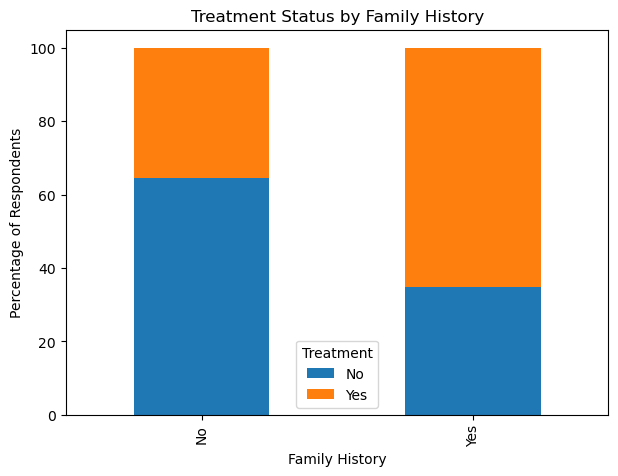

```python
family_treatment = pd.crosstab(
    healthcare['FamilyHistory'],
    healthcare['Treatment'],
    normalize='index'
) * 100

ax = family_treatment.plot(
    kind='bar', stacked=True, figsize=(7,5)
)

plt.title('Treatment Status by Family History')
plt.xlabel('Family History')
plt.ylabel('Percentage of Respondents')
plt.legend(title='Treatment')
plt.show()
```

The chart shows that the patients with family history have a higher treatment proportion. This finding helps the organisation to understand that employee mental health can differ according to family background. For technical concepts, the crosstab() function in pandas compares the 2 columns of the same table or dataset. Then, I have used simple bar chart to show how family history can affect on getting treatment.

### Insight 2: Does Gender and Treatment have any relation?

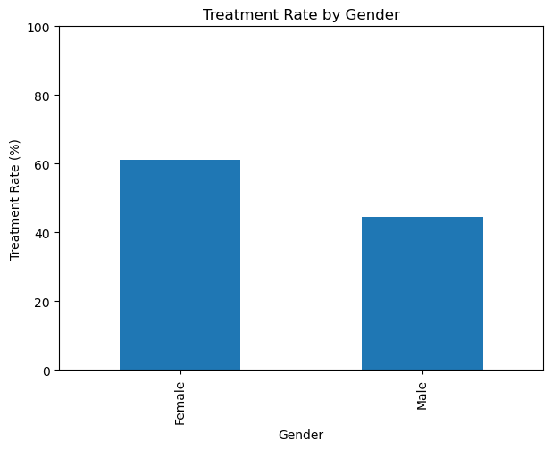

```python
gender_treatment = pd.crosstab(
    healthcare['Gender'],
    healthcare['Treatment'],
    normalize='index'
) * 100

gender_treatment['Yes'].plot(
    kind='bar', figsize=(7,5)
)

plt.title('Treatment Rate by Gender')
plt.xlabel('Gender')
plt.ylabel('Treatment Rate (%)')
plt.ylim(0,100)
plt.show()
```

Female respondents are prone to higher treatment rate than male respondents.

### Insight 3: Does Occupation has any affects on Increasing Stress?

```python
occupation_stress = pd.crosstab(
    healthcare['Occupation'],
    healthcare['IncreasingStress'],
    normalize='index'
) * 100

print(occupation_stress.round(2))
```

```
IncreasingStress  Maybe     No    Yes
Occupation
Business          34.64  26.60  38.76
Corporate         28.26  33.41  38.33
Housewife         36.54  33.90  29.56
Others            34.85  36.07  29.08
Student           37.70  26.49  35.80
```

The data shows that people in different occupations have different increasing stress rate like Business and Corporate has high rate of increasing stress. This relation will help in monitoring what occupation is more stressfull. Lets see these finding in a graph for better understanding.

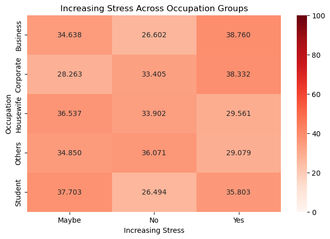

```python
import seaborn as sns

plt.figure(figsize=(8, 5))

sns.heatmap(
    occupation_stress,
    annot=True,
    fmt='.3f',
    cmap='Reds',
    vmin=0,
    vmax=100
)

plt.title('Increasing Stress Across Occupation Groups')
plt.xlabel('Increasing Stress')
plt.ylabel('Occupation')

plt.show()
```

### Insight 4: Does staying indoors for longer periods affects copping struggles?

```python
days_coping = pd.crosstab(
    healthcare['DaysIndoors'],
    healthcare['CopingStruggles'],
    normalize='index'
) * 100

print(days_coping.round(2))
```

```
CopingStruggles        No    Yes
DaysIndoors
1-14 days           59.98  40.02
15-30 days          55.75  44.25
31-60 days          47.73  52.27
Go out Every day    48.18  51.82
More than 2 months  52.13  47.87
```

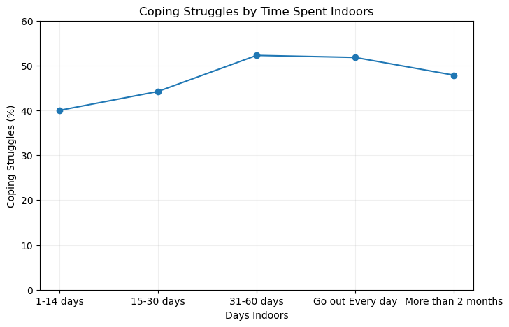

```python
coping_rate = days_coping['Yes']

plt.figure(figsize=(8, 5))
plt.plot(coping_rate.index, coping_rate.values, marker='o')
plt.title('Coping Struggles by Time Spent Indoors')
plt.xlabel('Days Indoors')
plt.ylabel('Coping Struggles (%)')
plt.ylim(0, 60)
plt.grid(True, alpha=0.2)
plt.show()
```

The chart shows that more number of days have higher coping struggle percentage. Although the longest time duration falls slightly lead by Go out everyday

### Insight 5: Does gender affects in opening up for mental health interviews?

```python
gender_interview = pd.crosstab(
    healthcare['Gender'],
    healthcare['MentalHealthInterview'],
    normalize='index'
) * 100

print(gender_interview.round(2))
```

```
MentalHealthInterview  Maybe     No   Yes
Gender
Female                 16.38  81.93  1.70
Male                   29.09  62.08  8.83
```

The outputs tells that Females have higher rate of saying No for mental health interviews compared to Male respondents. Lets see this in a chart for clear understanding:

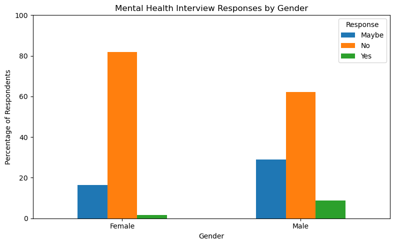

```python
gender_interview.plot(
    kind='bar',
    figsize=(8, 5)
)

plt.title('Mental Health Interview Responses by Gender')
plt.xlabel('Gender')
plt.ylabel('Percentage of Respondents')
plt.xticks(rotation=0)
plt.ylim(0, 100)
plt.legend(title='Response')
plt.tight_layout()
plt.show()
```

### Insight 6: How do respondents percieve the availability of mental health care options?

```python
care_counts = healthcare['CareOptions'].value_counts()

print(care_counts)
print((care_counts / len(healthcare) * 100).round(2))
```

```
CareOptions
No          34285
Yes         25684
Not sure    22106
Name: count, dtype: int64
CareOptions
No          41.77
Yes         31.29
Not sure    26.93
Name: count, dtype: float64
```

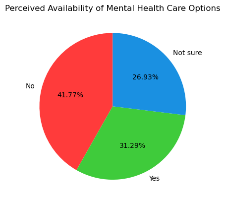

```python
plt.pie(
    care_counts.values,
    labels=care_counts.index,
    autopct='%1.2f%%',
    startangle=90,
    colors=['#ff3b3b','#3fcb3b', '#1a90e1'] #No = Softred, Yes=SoftGreen, NotSure=Softblue
)

plt.title('Perceived Availability of Mental Health Care Options')
plt.show()
```

Pie chart shows the distribution of responses to the mental health care otions availability.

### Insight 7: What countries have high number of respondents?

```python
country_counts = healthcare['Country'].value_counts()

print(country_counts.head(10))
print((country_counts.head(10) / len(healthcare) * 100).round(2))
```

```
Country
USA            21774
UK             15399
Canada          8225
Germany         4232
Netherlands     3720
Ireland         3589
Australia       3114
Sweden          2028
India           1796
New Zealand     1789
Name: count, dtype: int64
Country
USA            26.53
UK             18.76
Canada         10.02
Germany         5.16
Netherlands     4.53
Ireland         4.37
Australia       3.79
Sweden          2.47
India           2.19
New Zealand     2.18
Name: count, dtype: float64
```

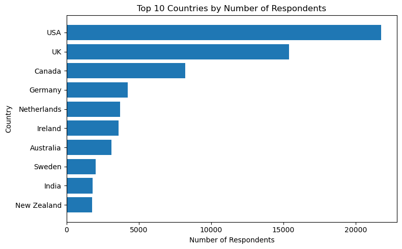

```python
top_countries = country_counts.head(10).sort_values()

plt.figure(figsize=(8, 5))
plt.barh(top_countries.index, top_countries.values)

plt.title('Top 10 Countries by Number of Respondents')
plt.xlabel('Number of Respondents')
plt.ylabel('Country')
plt.tight_layout()
plt.show()
```

We have selected top 10 countries with the highest number of respondent. From those top 10 only USA and UK make the most of number of respondents. I have used horizontal bar graph to show the top 10 countries in Ascending order on the bases of number of respondents from each country. This data tells the organisations that what respondents from which countries are more willing to participate in data gathering.

## Final Discussion and Conclusion:

I have stated business context, explored data, completed preprocessing of data and from that clean and structure date I have derived some useful insights. Lets dive into final part on discussion on strengths and weakness of data analysis, implications of the results and data driven recommendations for client company.

### Strengths and Limitations:

Strengths includes large clean dataset with almost 82000 entries. Missing, duplicated and invalid values were addressed. Dataset had multiple variables to explore the different aspect of mental health, workplace wellbeing and care options availibility. While on the other there were some limitation in data analysis most importantly the dataset does not represent wider population from a lot of countries. Some relation were weak and could not help in extracting a meaningful insights. The dataset has uneven country representation which hinders in finding relations on country level.

### Data Driven Recommendations:

1. Improvement of awareness of available support is necessary because even if a lot of support is availabe but people do not even know about so the support has not use.
2. As lot people declined participating in mental health interviews so confidential support channels are very good option.
3. In business and corporate occupation people experienced increasing stress so workplace wellbeing should be implemented.
4. Family history affect treats so early support is a good advantage in getting good results.
5. Data was not collected evenly and widely so more data can help in making decision on country level or even city levels.

## References:

Kaggle dataset

Alam Shihab (2025) Mental Health Dataset. Kaggle. Available at: https://www.kaggle.com/datasets/alamshihab075/mental-health-dataset (Accessed: 13 September 2026).

Pandas

The pandas development team (2026) pandas documentation: pandas.crosstab. Available at: pandas.crosstab documentation (Accessed: 14 September 2026).

Matplotlib

The Matplotlib development team (2026) Matplotlib documentation: matplotlib.pyplot.bar. Available at: Matplotlib bar documentation (Accessed: 15 September 2026).

Seaborn

Waskom, M. (2026) seaborn.heatmap documentation. Available at: Seaborn heatmap documentation (Accessed: 15 September 2026).